# MultiSpectralGrowth_manuscript

Sylwia Sliwinska-Wilczewska<sup>1,2</sup>, Naaman Oman<sup>1</sup>, Mireille Savoie<sup>1</sup>, Maximilian Berthold<sup>1</sup>, and Douglas A. Campbell<sup>1</sup>

<sup>1</sup> Department of Biology, Mount Allison University, 53 York St., Sackville NB, Canada, E4L 1C9  
<sup>2</sup> Institute of Oceanography, University of Gdansk, 46 Pilsudskiego St, P81-378, Gdynia, Poland

```r
FiguresFP <- file.path("SySl_MultiSpectralGrowth_manuscript_files", "figure-html")
```

# Introduction

Note: What is the target journal and content for this assessment of spectral and O2 influences on growth of Baltic strains? It could clearly hit some ‘local’ journal on Baltic coastal issues. Is there potential for wider conclusions for a wide journal?

Functional analyses to complete the growth and pigment plots:

-Solisense light response curves under all five actinic light colours. So, for example, PSII ETR vs. colour and/or JVPSII vs. colour Needs Doug to implement new PSII ETR and/or JVPSII; on Doug’s list.

-OLIS spectra could be deconvoluted to pigment pools at Days many repeats Possibly focus on achieved pigment pool after XX days; ecologically relevant Mixing rates? Eddy duration?…. Or just pick a baseline period Or achieved pigment pools from mid-exponential vs. stationary….???? Or after so many rounds of cell division….

Something to rationally motivate choices of what data are presented.

Consider fitting growth rate vs. spectra with a function (or interpolate) to compare to JVPSII vs. spectra Is growth rate pattern mirroring JVPSII or do other factors intervene?

With correct unit choices we can plot growth return on JVPSII (or on PSII ETR) across spectra….

Use OLIS spectra to generate a* etc. a* is the achieved absorbance per unit chlorophyll a* can be across PAR or waveband specific

Calculation is a bit confusing but we can work it out.

Attempt to use O2 calibration to get absolute values for JVPSII…

Doug tasks: -add JVPSII and new PSII ETR

Sylwia tasks: Continue to plot data -OLIS import and plot representative spectra -consider OLIS deconvolution (consult with Doug as needed; do not be stuck!)

Use OLIS spectral deconvolution to express PE/PC as index of (Complementary) Chromatic Acclimation

Experimental Work: *Probably add low O2 for BA127R*

# Material and Methods

## Statistical analysis

We used R (Team, 2019) running under RStudio (Team, 2015), using packages “tidyverse” (Wickham, 2021), “glue” (Hester and Bryan, 2022), “googlesheets4” (Bryan, 2021), “kableExtra” (Zhu, 2021).

# Results

Note: Are there any validations of [O2] with optode for ‘low O2?’ In remaining runs test achieved low O2 range With Mireille we found wide variation in growth responses in tubes that were consistently ~< 5 µmol O2 l-1 compared to tubes that were ~ 20 µmol O2 l-1

1. Clear difference in growth response to spectral range
2. Evidence for combined toxicity of O2 x 405 nm b/c growth faster under low O2 x 405 nm

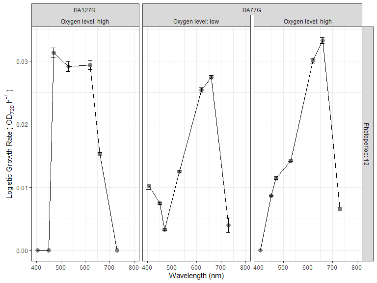

Figure 1: Growth rate - Logistic OD720 (MultiCulti)

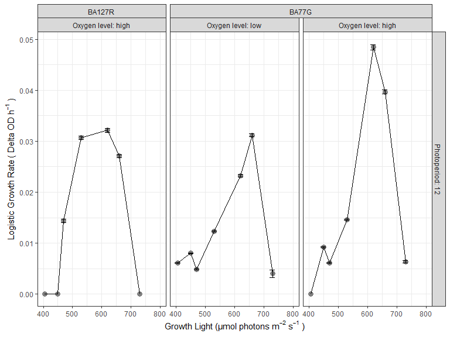

Figure 2: Growth rate - Logistic Delta (MultiCulti)

Possibly interesting differences in patterns of fitted logistic growth rate vs. achieved absorbance after 7 days! Possibly presentation approach is to present growth achievement over 7 days (or other window) rather than nominal fitted growth rate

Note: Figure Caption Numbering messed up in HTML Avoid spaces in r chunk names for auto-numbering

Consider some XY cross plots and regressions among different metrics of chlorophyll for Supplemental results. Use fitted linear model NOT the ggplot geom_smooth b/c we need to be sure that fitted models are actually based upon the presented data.

Cross plots of Pico cell counts vs. PAMAS and vs. OD750 etc. Possible discrepancy with results from Gdansk calibration curves from flow cytometer?

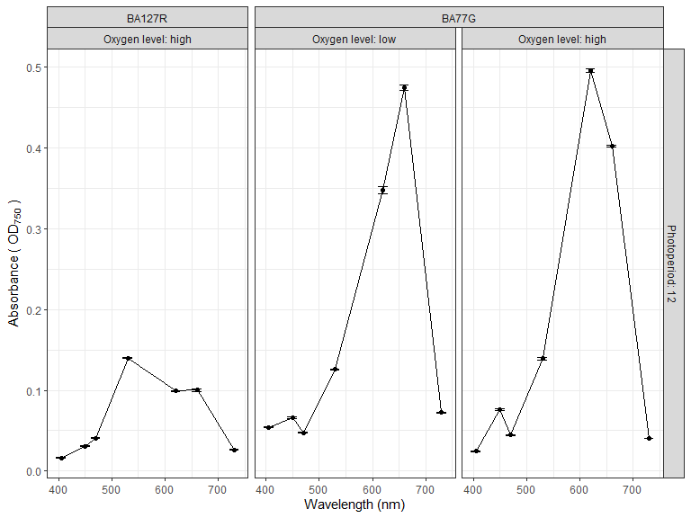

Figure 3: Absorbance - OD750 (ClarioSTAR)

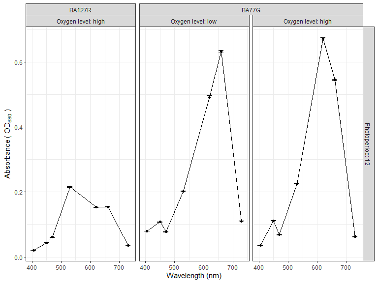

Figure 4: Absorbance - OD680 (ClarioSTAR)

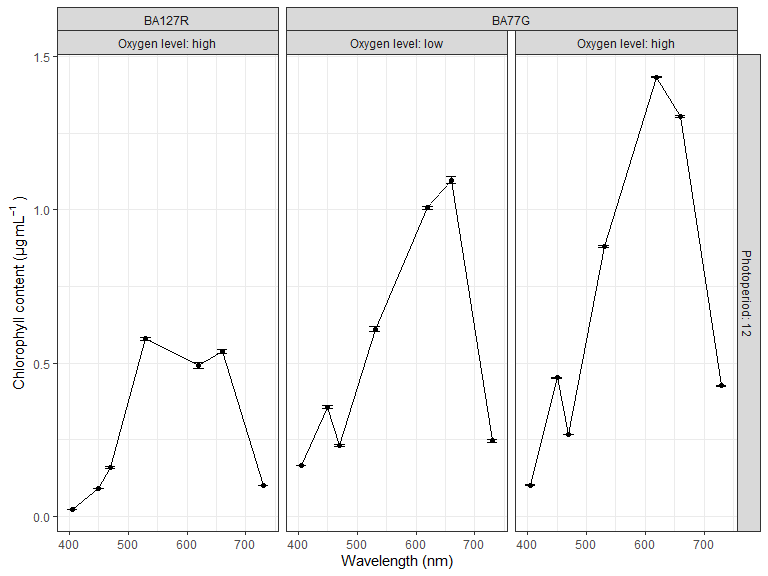

Figure 5: Chl a ug/mL (Turner)

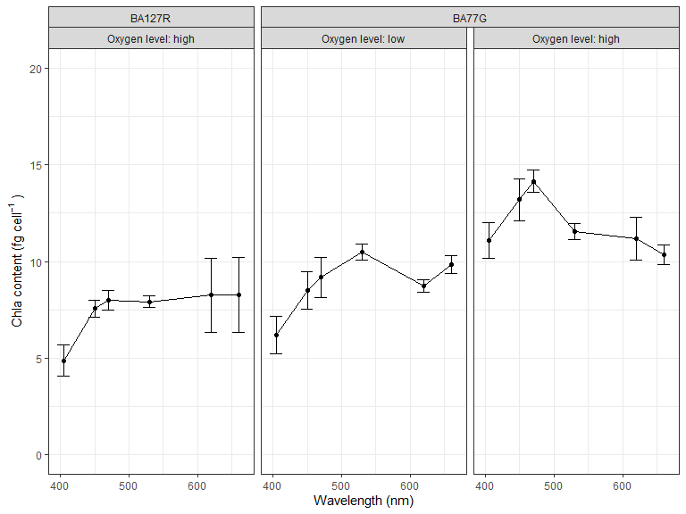

Figure 6: Chl a fg/cell (Turner)

Re-set sizes of .png upon generation

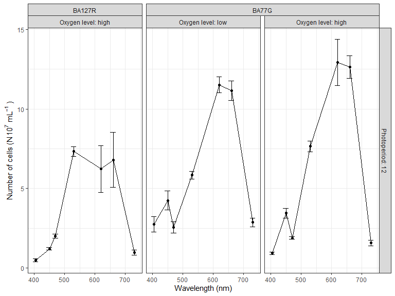

Figure 7: N 10^7 cell/mL (MD Pico cytometer)

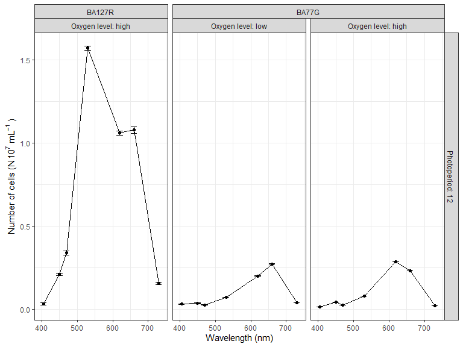

Figure 8: N 10<sup>7</sup> cell/mL (BD Accurri flowcytometer)

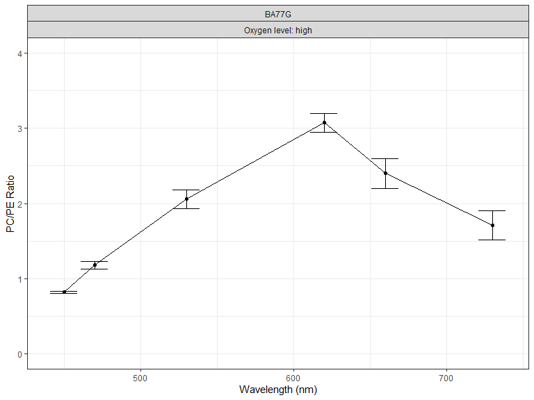

Figure 9: PC/PE Ratio (Filters)

OLIS based PC/PE ratios; incomplete data from filters PC/PE or PE/PC? Also PC/Chl and PE/Chl?

# References

Bryan, J., 2021. googlesheets4: Access google sheets using the sheets API V4.

Hester, J., Bryan, J., 2022. Glue: Interpreted string literals.

Team, R.C., 2019. R: A Language and Environment for Statistical Computing. R Fundation for Statistical Computing, Vienna, Austria.

Team, Rs., 2015. RStudio: Integrated Development Environment for R. RStudio, Inc., Boston, MA.

Wickham, H., 2021. Tidyverse: Easily install and load the tidyverse.

Zhu, H., 2021. kableExtra: Construct complex table with kable and pipe syntax.